# Project 1

# Part 3: Convert wide data into long data

The goal of this part of the assignment is to take a dataset that is either messy or simply not tidy and to make them tidy datasets. The objective is to gain some familiarity with the functions in the `dplyr`, `tidyr` packages. You may find it helpful to review the section on pivoting data from wide to long format and vice versa.

### Tasks

We are going to create a set of features for us to plot over time. Use the functions in `dplyr` and `tidyr` to perform the following steps to the `chocolate` dataset:

1. Create a new set of columns titled `beans`, `sugar`, `cocoa_butter`, `vanilla`, `letchin`, and `salt` that contain a 1 or 0 representing whether or not that review for the chocolate bar contained that ingredient (1) or not (0).

```r
library(stringr)

choco_tidy <- chocolate %>%
  extract(
    col = ingredients,
    into = c("ingred_number", "ingred_list"),
    regex = "([1-5])-\\s*([A-Z,]+)"
  )

choco_tidy <- choco_tidy %>%
  mutate(
    beans = case_when(str_detect(ingred_list, "B") ~ 1, TRUE ~ 0),
    sugar = case_when(str_detect(ingred_list, "S") ~ 1, TRUE ~ 0),
    cocoa_butter = case_when(str_detect(ingred_list, "C") ~ 1, TRUE ~ 0),
    vanilla = case_when(str_detect(ingred_list, "V") ~ 1, TRUE ~ 0),
    lecithin = case_when(str_detect(ingred_list, "L") ~ 1, TRUE ~ 0),
    salt = case_when(str_detect(ingred_list, "Sa") ~ 1, TRUE ~ 0)  #There is no salt in the ingredients list
  )
```

2. Create a new set of columns titled `char_cocoa`, `char_sweet`, `char_nutty`, `char_creamy`, `char_roasty`, `char_earthy` that contain a 1 or 0 representing whether or not that the most memorable characteristic for the chocolate bar had that word (1) or not (0). For example, if the word “sweet” appears in the `most_memorable_characteristics`, then record a 1, otherwise a 0 for that review in the `char_sweet` column (**Hint**: check out `str_detect()` from the `stringr` package).

```r
choco_tidy <- choco_tidy %>%
  mutate(
    char_cocoa = case_when(str_detect(most_memorable_characteristics, "cocoa") ~ 1, TRUE ~ 0),
    char_sweet = case_when(str_detect(most_memorable_characteristics, "sweet") ~ 1, TRUE ~ 0),
    char_nutty = case_when(str_detect(most_memorable_characteristics, "nutty") ~ 1, TRUE ~ 0),
    char_creamy = case_when(str_detect(most_memorable_characteristics, "creamy") ~ 1, TRUE ~ 0),
    char_roasty = case_when(str_detect(most_memorable_characteristics, "roasty") ~ 1, TRUE ~ 0),
    char_earthy = case_when(str_detect(most_memorable_characteristics, "earthy") ~ 1, TRUE ~ 0)
  )
```

3. For each year (i.e. `review_date`), calculate the mean value in each new column you created across all reviews for that year. (**Hint**: If all has gone well thus far, you should have a dataset with 16 rows and 13 columns).

```r
ing_char <- choco_tidy %>%
  group_by(review_date) %>%
  summarize(beans = mean(beans),
            sugar = mean(sugar),
            cocoa_butter = mean(cocoa_butter),
            vanilla = mean(vanilla),
            lecithin = mean(lecithin),
            salt = mean(salt),
            char_cocoa = mean(char_cocoa),
            char_sweet = mean(char_sweet),
            char_nutty = mean(char_nutty),
            char_creamy = mean(char_creamy),
            char_roasty = mean(char_roasty),
            char_earthy = mean(char_earthy))

#A more concise option:

#ing_char <- choco_tidy %>%
#  group_by(review_date) %>%
#  summarize(across(c(beans, sugar, cocoa_butter, vanilla, lecithin, salt,
#                     char_cocoa, char_sweet, char_nutty, char_creamy,
#                     char_roasty, char_earthy), mean))
```

4. Convert this wide dataset into a long dataset with a new `feature` and `mean_score` column.

It should look something like this:

```
review_date     feature   mean_score
<dbl>           <chr>     <dbl>
2006    beans   0.967741935
2006    sugar   0.967741935
2006    cocoa_butter    0.903225806
2006    vanilla 0.693548387
2006    letchin 0.693548387
2006    salt    0.000000000
2006    char_cocoa  0.209677419
2006    char_sweet  0.161290323
2006    char_nutty  0.032258065
2006    char_creamy 0.241935484
```

### Notes

- You may need to use functions outside these packages to obtain this result.
- Do not worry about the ordering of the rows or columns. Depending on whether you use `gather()` or `pivot_longer()`, the order of your output may differ from what is printed above. As long as the result is a tidy data set, that is sufficient.

```r
ing_char <- ing_char %>%
  pivot_longer(cols = -review_date,
               names_to = "feature",
               values_to = "meanscore")
```

# Part 4: Data visualization

### Tasks

Use the functions in `ggplot2` package to make a scatter plot of the `mean_score`s (y-axis) over time (x-axis). There should be one plot (facet) for each `feature`. For full credit, your plot should include:

1. An overall title for the plot and a subtitle summarizing key trends that you found. Also include a caption in the figure with your name.
2. Both the observed points for the `mean_score`, but also a smoothed non-linear pattern of the trend
3. All plots should be shown in the one figure
4. There should be an informative x-axis and y-axis label

Consider playing around with the `theme()` function to make the figure shine, including playing with background colors, font, etc. See https://github.com/lcolladotor/jhustatcomputing/issues/4 for an example on how you can choose colors if you have too many categories.

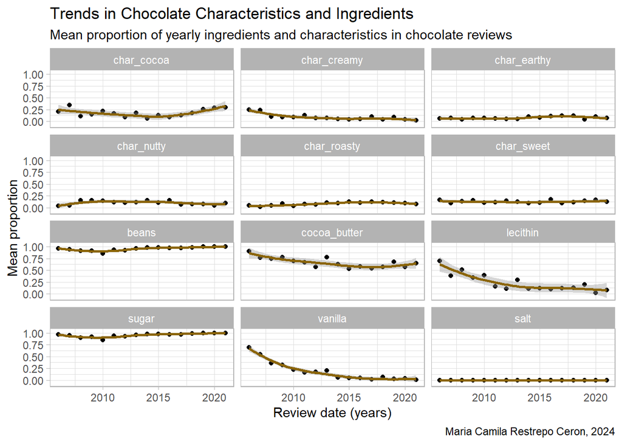

```r
ing_char$feature <- factor(ing_char$feature,
                           levels = c("char_cocoa", "char_creamy", "char_earthy",
                                      "char_nutty", "char_roasty", "char_sweet",
                                      "beans", "cocoa_butter", "lecithin",
                                      "sugar", "vanilla", "salt"))

ggplot(ing_char, aes(x = review_date, y = meanscore)) +
  geom_point() +
  facet_wrap( ~ feature, ncol = 3) +
  geom_smooth(color = "darkgoldenrod4") +
  ggtitle("Trends in Chocolate Characteristics and Ingredients", "Mean proportion of yearly ingredients and characteristics in chocolate reviews") +
  labs(x = "Review date (years)",
       y = "Mean proportion",
       caption = "Maria Camila Restrepo Ceron, 2024") +
  theme(plot.title = element_text(face = "bold")) +
  theme_light()
```

```r
apropos("theme_") #to look up the existing themes
```

```
##  [1] "register_theme_elements" "reset_theme_settings"
##  [3] "theme_bw"                "theme_classic"
##  [5] "theme_dark"              "theme_get"
##  [7] "theme_gray"              "theme_grey"
##  [9] "theme_light"             "theme_linedraw"
## [11] "theme_minimal"           "theme_replace"
## [13] "theme_set"               "theme_test"
## [15] "theme_update"            "theme_void"
```

# Part 5: Make the worst plot you can!

This sounds a bit crazy I know, but I want this to try and be FUN! Instead of trying to make a “good” plot, I want you to explore your creative side and make a really awful data visualization in every way. :)

### Tasks

Using the `chocolate` dataset (or any of the modified versions you made throughout this assignment or anything else you wish you build upon it):

1. Make the absolute worst plot that you can. You need to customize it in **at least 7 ways** to make it awful.

```r
choco_10reviews <- choco_10reviews %>%
  mutate( colombia =
    case_when(country_of_bean_origin == "Colombia" ~ 1, TRUE ~ 0)
  )

choco_10reviews <- choco_10reviews %>%
  mutate(colombia = factor(colombia,
                           levels = c(1, 0),
                           labels = c("Colombia! <3", "Not Colombia X")))
str(choco_10reviews$colombia)
```

```
##  Factor w/ 2 levels "Colombia! <3",..: 2 2 2 2 2 2 2 2 2 1 ...
```

```r
choco_10reviews %>%
  group_by(colombia) %>%
  summarise(count = n())
```

```
## # A tibble: 2 × 2
##   colombia       count
##   <fct>          <int>
## 1 Colombia! <3      79
## 2 Not Colombia X  2213
```

[figure not shown]

```r
#Add an image to the background
library(grid)
#install.packages("png")
library(png)
img <- rasterGrob(readPNG("sombrero-vueltiao.png"), width = unit(1, "npc"), height = unit(1, "npc"))


ggplot(choco_10reviews, aes(x = colombia, y = rating)) +
  annotation_custom(img, xmin = -Inf, xmax = Inf, ymin = 1.40, ymax = 3.60) +
  geom_boxplot(color = "blue") +
  ggtitle("Colombian chocolate is as good as our coffee") +
  labs(x = "Cacao bean origin", y = "Rating", caption = "Que viva Shakira y Sofia Vergara") +
  theme(
    plot.background = element_rect(fill = "yellow", color = NA),
    panel.background = element_rect(fill = "transparent", color = NA),
    plot.title = element_text(size = 20, color = "blue", hjust = 0.5),
    axis.title.x = element_text(size = 16, color = "red", face = "italic"),
    axis.title.y = element_text(size = 16, color = "red", face = "italic"),
    axis.text.x = element_text(size = 14),
    axis.text.y = element_text(size = 14)
  )
```

2. In your document, write 1 - 2 sentences about each different customization you added (using bullets – i.e. there should be at least 7 bullet points each with 1-2 sentences), and how it could be useful for you when you want to make an awesome data visualization.
- Background picture: through the png and grid package, I added a picture to the background, customizing the size and location according to the x and y axis.
- Boxplot: to match the “colombia” theme, I changed the color of the boxplots to blue.
- Title: I added a title, increased the font size, and changed the color to blue.
- Axis labels: I changed the axis labels, increased the font size, changed the color to red, and italicized them.
- Caption: I added a caption to the graph.
- Background color: I changed the background color to yellow to fit the theme.
- Panel background: In order for the background picture to show, I had to change the panel background to transparent.
- Axis text: I increased the font size of the x and y axis.